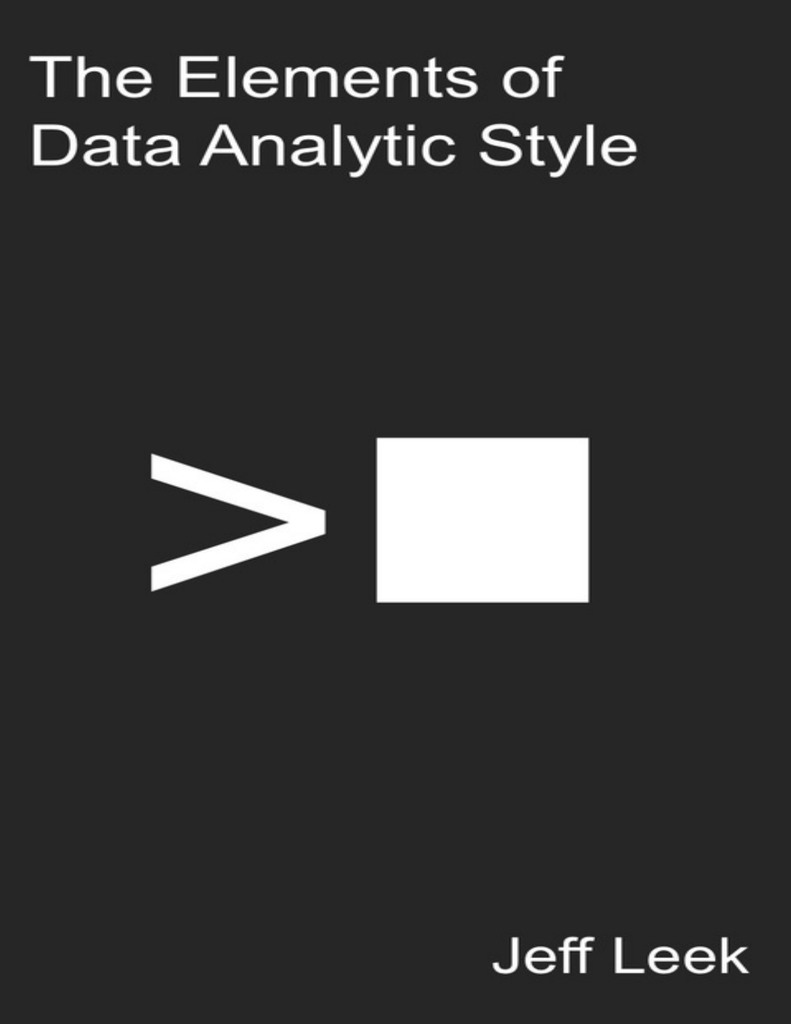

[figure not shown]

The Elements of Data Analytic Style

A guide for people who want to analyze data.

Jeff Leek

This book is for sale at http://leanpub.com/datastyle

This version was published on 2015-03-02

* * * * *

This is a Leanpub book. Leanpub empowers authors and publishers with the

Lean Publishing process. Lean Publishing is the act of publishing an in-

progress ebook using lightweight tools and many iterations to get reader

feedback, pivot until you have the right book and build traction once you

do.

* * * * *

© 2014 - 2015 Jeff Leek

An @simplystats publication.

Thank you to Karl Broman and Alyssa Frazee for constructive and really

helpful feedback on the first draft of this manuscript. Thanks to Roger Peng,

Brian Caffo, and Rafael Irizarry for helpful discussions about data

analysis.

[figure not shown]

Table of Contents

1. Introduction

2. The data analytic question

3. Tidying the data

4. Checking the data

5. Exploratory analysis

6. Statistical modeling and inference

7. Prediction and machine learning

8. Causality

9. Written analyses

10. Creating figures

11. Presenting data

12. Reproducibility

13. A few matters of form

14. The data analysis checklist

15. Additional resources

[figure not shown]

1. Introduction

The dramatic change in the price and accessibility of data demands a new

focus on data analytic literacy. This book is intended for use by people who

perform regular data analyses. It aims to give a brief summary of the key

ideas, practices, and pitfalls of modern data analysis. One goal is to

summarize in a succinct way the most common difficulties encountered by

practicing data analysts. It may serve as a guide for peer reviewers who

may refer to specific section numbers when evaluating manuscripts. As will

become apparent, it is modeled loosely in format and aim on the Elements

of Style by William Strunk.

The book includes a basic checklist that may be useful as a guide for

beginning data analysts or as a rubric for evaluating data analyses. It has

been used in the author’s data analysis class to evaluate student projects.

Both the checklist and this book cover a small fraction of the field of data

analysis, but the experience of the author is that once these elements are

mastered, data analysts benefit most from hands on experience in their own

discipline of application, and that many principles may be non-transferable

beyond the basics.

If you want a more complete introduction to the analysis of data one option

is the free Johns Hopkins Data Science Specialization.

As with rhetoric, it is true that the best data analysts sometimes disregard

the rules in their analyses. Experts usually do this to reveal some

characteristic of the data that would be obscured by a rigid application of

data analytic principles. Unless an analyst is certain of the improvement,

they will often be better served by following the rules. After mastering the

basic principles, analysts may look to experts in their subject domain for

more creative and advanced data analytic ideas.

2. The data analytic question

2.1 Define the data analytic question first

Data can be used to answer many questions, but not all of them. One of the

most innovative data scientists of all time said it best.

The data may not contain the answer. The combination of some data

and an aching desire for an answer does not ensure that a reasonable

answer can be extracted from a given body of data.

John Tukey

Before performing a data analysis the key is to define the type of question

being asked. Some questions are easier to answer with data and some are

harder. This is a broad categorization of the types of data analysis questions,

ranked by how easy it is to answer the question with data. You can also use

the data analysis question type flow chart to help define the question type

(Figure 2.1)

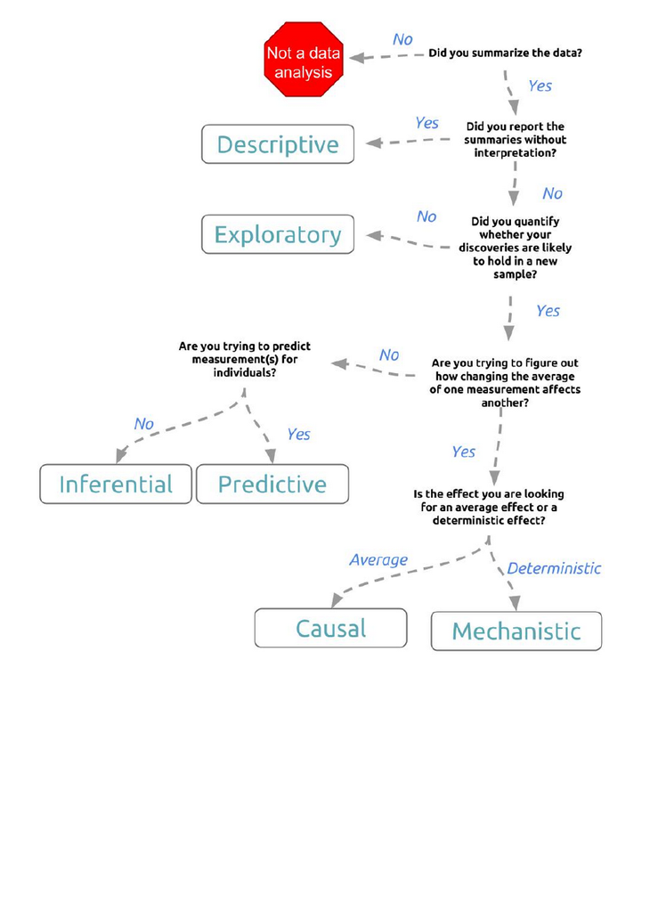

Figure 2.1 The data analysis question type flow chart

2.2 Descriptive

A descriptive data analysis seeks to summarize the measurements in a

single data set without further interpretation. An example is the United

States Census. The Census collects data on the residence type, location, age,

sex, and race of all people in the United States at a fixed time. The Census

is descriptive because the goal is to summarize the measurements in this

fixed data set into population counts and describe how many people live in

different parts of the United States. The interpretation and use of these

counts is left to Congress and the public, but is not part of the data analysis.

2.3 Exploratory

An exploratory data analysis builds on a descriptive analysis by searching

for discoveries, trends, correlations, or relationships between the

measurements of multiple variables to generate ideas or hypotheses. An

example is the discovery of a four-planet solar system by amateur

astronomers using public astronomical data from the Kepler telescope. The

data was made available through the planethunters.org website, that asked

amateur astronomers to look for a characteristic pattern of light indicating

potential planets. An exploratory analysis like this one seeks to make

discoveries, but rarely can confirm those discoveries. In the case of the

amateur astronomers, follow-up studies and additional data were needed to

confirm the existence of the four-planet system.

2.4 Inferential

An inferential data analysis goes beyond an exploratory analysis by

quantifying whether an observed pattern will likely hold beyond the data set

in hand. Inferential data analyses are the most common statistical analysis

in the formal scientific literature. An example is a study of whether air

pollution correlates with life expectancy at the state level in the United

States. The goal is to identify the strength of the relationship in both the

specific data set and to determine whether that relationship will hold in

future data. In non-randomized experiments, it is usually only possible to

observe whether a relationship between two measurements exists. It is often

impossible to determine how or why the relationship exists - it could be due

to unmeasured data, relationships, or incomplete modeling.

2.5 Predictive

While an inferential data analysis quantifies the relationships among

measurements at population-scale, a predictive data analysis uses a subset

of measurements (the features) to predict another measurement (the

outcome) on a single person or unit. An example is when organizations like

FiveThirtyEight.com use polling data to predict how people will vote on

election day. In some cases, the set of measurements used to predict the

outcome will be intuitive. There is an obvious reason why polling data may

be useful for predicting voting behavior. But predictive data analyses only

show that you can predict one measurement from another, they don’t

necessarily explain why that choice of prediction works.

2.6 Causal

A causal data analysis seeks to find out what happens to one measurement

if you make another measurement change. An example is a randomized

clinical trial to identify whether fecal transplants reduces infections due to

Clostridium dificile. In this study, patients were randomized to receive a

fecal transplant plus standard care or simply standard care. In the resulting

data, the researchers identified a relationship between transplants and

infection outcomes. The researchers were able to determine that fecal

transplants caused a reduction in infection outcomes. Unlike a predictive or

inferential data analysis, a causal data analysis identifies both the magnitude

and direction of relationships between variables.

2.7 Mechanistic

Causal data analyses seek to identify average effects between often noisy

variables. For example, decades of data show a clear causal relationship

between smoking and cancer. If you smoke, it is a sure thing that your risk

of cancer will increase. But it is not a sure thing that you will get cancer.

The causal effect is real, but it is an effect on your average risk. A

mechanistic data analysis seeks to demonstrate that changing one

measurement always and exclusively leads to a specific, deterministic

behavior in another. The goal is to not only understand that there is an

effect, but how that effect operates. An example of a mechanistic analysis is

analyzing data on how wing design changes air flow over a wing, leading to

decreased drag. Outside of engineering, mechanistic data analysis is

extremely challenging and rarely undertaken.

2.8 Common mistakes

2.8.1 Correlation does not imply causation

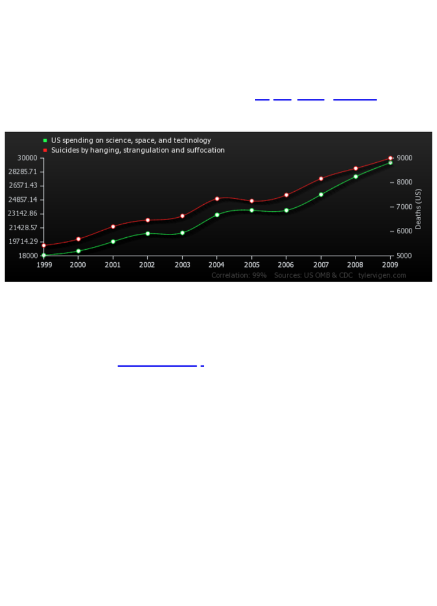

Interpreting an inferential analysis as causal.

Most data analyses involve inference or prediction. Unless a randomized

study is performed, it is difficult to infer why there is a relationship between

two variables. Some great examples of correlations that can be calculated

but are clearly not causally related appear at http://tylervigen.com/ (Figure

2.2).

Figure 2.2 A spurious correlation

Particular caution should be used when applying words such as “cause” and

“effect” when performing inferential analysis. Causal language applied to

even clearly labeled inferential analyses may lead to misinterpretation - a

phenomenon called causation creep.

2.8.2 Overfitting

Interpreting an exploratory analysis as predictive

A common mistake is to use a single, unsplit data set for both model

building and testing. If you apply a prediction model to the same data set

used to build the model you can only estimate “resubstitution error” or

“training set error”. These estimates are very optimistic estimates of the

error you would get if using the model in practice. If you try enough models

on the same set of data, you eventually can predict perfectly.

2.8.3 n of 1 analysis

[figure not shown]

Descriptive versus inferential analysis.

When you have a very small sample size, it is often impossible to explore

the data, let alone make inference to a larger population. An extreme

example is when measurements are taken on a single person or sample.

With this kind of data it is possible to describe the person or sample, but

generally impossible to infer anything about a population they come from.

2.8.4 Data dredging

Interpreting an exploratory analysis as inferential

Similar to the idea of overfitting, if you fit a large number of models to a

data set, it is generally possible to identify at least one model that will fit

the observed data very well. This is especially true if you fit very flexible

models that might also capture both signal and noise. Picking any of the

single exploratory models and using it to infer something about the whole

population will usually lead to mistakes. As Ronald Coase said:

“If you torture the data enough, nature will always confess.”

This chapter builds on and expands the paper “What is the question?” co-

authored by the author of this book.

3. Tidying the data

The point of creating a tidy data set is to get the data into a format that can

be easily shared, computed on, and analyzed.

3.1 The components of a data set

The work of converting the data from raw form to directly analyzable form

is the first step of any data analysis. It is important to see the raw data,

understand the steps in the processing pipeline, and be able to incorporate

hidden sources of variability in one’s data analysis. On the other hand, for

many data types, the processing steps are well documented and

standardized.

These are the components of a processed data set:

1. The raw data.

2. A tidy data set.

3. A code book describing each variable and its values in the tidy data

set.

4. An explicit and exact recipe you used to go from 1 to 2 and 3.

3.2 Raw data

It is critical that you include the rawest form of the data that you have

access to. Some examples of the raw form of data are as follows.

1. The strange binary file your measurement machine spits out

2. The unformatted Excel file with 10 worksheets the company you

contracted with sent you

3. The complicated JSON data you got from scraping the Twitter API

4. The hand-entered numbers you collected looking through a

microscope

[figure not shown]

You know the raw data is in the right format if you ran no software on the

data, did not manipulate any of the numbers in the data, did not remove any

data from the data set, and did not summarize the data in any way.

If you did any manipulation of the data at all it is not the raw form of the

data. Reporting manipulated data as raw data is a very common way to slow

down the analysis process, since the analyst will often have to do a forensic

study of your data to figure out why the raw data looks weird.

3.3 Raw data is relative

The raw data will be different to each person that handles the data. For

example, a machine that measures blood pressure does an internal

calculation that you may not have access to when you are given a set of

blood pressure measurements. In general you should endeavor to obtain the

rawest form of the data possible, but some pre-processing is usually

inevitable.

3.4 Tidy data

The general principles of tidy data are laid out by Hadley Wickham in this

paper and this video. The paper and the video are both focused on the R

package, which you may or may not know how to use. Regardless the four

general principles you should pay attention to are:

Each variable you measure should be in one column

Each different observation of that variable should be in a different row

There should be one table for each “kind” of variable

If you have multiple tables, they should include a column in the table

that allows them to be linked

While these are the hard and fast rules, there are a number of other things

that will make your data set much easier to handle.

3.5 Include a row at the top of each data

table/spreadsheet that contains full row names.

So if you measured age at diagnosis for patients, you would head that

column with the name AgeAtDiagnosis instead of something like ADx or

another abbreviation that may be hard for another person to understand.

3.6 If you are sharing your data with the collaborator in

Excel, the tidy data should be in one Excel file per table.

They should not have multiple worksheets, no macros should be applied to

the data, and no columns/cells should be highlighted. Alternatively share

the data in a CSV or TAB-delimited text file.

3.7 The code book

For almost any data set, the measurements you calculate will need to be

described in more detail than you will sneak into the spreadsheet. The code

book contains this information. At minimum it should contain:

Information about the variables (including units!) in the data set not

contained in the tidy data

Information about the summary choices you made

Information about the experimental study design you used

In our genomics example, the analyst would want to know what the unit of

measurement for each clinical/demographic variable is (age in years,

treatment by name/dose, level of diagnosis and how heterogeneous). They

would also want to know how you picked the exons you used for

summarizing the genomic data (UCSC/Ensembl, etc.). They would also

want to know any other information about how you did the data

collection/study design. For example, are these the first 20 patients that

walked into the clinic? Are they 20 highly selected patients by some

characteristic like age? Are they randomized to treatments?

A common format for this document is a Word file. There should be a

section called “Study design” that has a thorough description of how you

collected the data. There is a section called “Code book” that describes each

variable and its units.

3.8 The instruction list or script must be explicit

You may have heard this before, but reproducibility is kind of a big deal in

computational science. That means, when you submit your paper, the

reviewers and the rest of the world should be able to exactly replicate the

analyses from raw data all the way to final results. If you are trying to be

efficient, you will likely perform some summarization/data analysis steps

before the data can be considered tidy.

3.9 The ideal instruction list is a script

The ideal thing for you to do when performing summarization is to create a

computer script (in R, Python, or something else) that takes the raw data as

input and produces the tidy data you are sharing as output. You can try

running your script a couple of times and see if the code produces the same

output.

3.10 If there is no script, be very detailed about

parameters, versions, and order of software

In many cases, the person who collected the data has incentive to make it

tidy for a statistician to speed the process of collaboration. They may not

know how to code in a scripting language. In that case, what you should

provide the statistician is something called pseudocode. It should look

something like:

Step 1 - take the raw file, run version 3.1.2 of summarize software

with parameters a=1, b=2, c=3

Step 2 - run the software separately for each sample

Step 3 - take column three of outputfile.out for each sample and that is

the corresponding row in the output data set

You should also include information about which system

(Mac/Windows/Linux) you used the software on and whether you tried it

more than once to confirm it gave the same results. Ideally, you will run this

by a fellow student/labmate to confirm that they can obtain the same output

file you did.

3.11 Common mistakes

3.11.1 Combining multiple variables into a single column

A common mistake is to make one column in a data set represent two

variables. For example, combining sex and age range into a single variable.

.

3.11.2 Merging unrelated data into a single file

If you have measurements on very different topics - for example a person’s

finance and their health - it is often a better idea to save each one as a

different table or data set with a common identifier.

3.11.3 An instruction list that isn’t explicit

When an instruction list that is not a computer script is used, a common

mistake is to not report the parameters or versions of software used to

perform an analysis.

This chapter builds on and expands the book author’s data sharing guide.

4. Checking the data

Data munging or processing is required for basically every data set that you

will have access to. Even when the data are neatly formatted like you get

from open data sources like Data.gov, you’ll frequently need to do things

that make it slightly easier to analyze or use the data for modeling.

The first thing to do with any new data set is to understand the quirks of the

data set and potential errors. This is usually done with a set of standard

summary measures. The checks should be performed on the rawest version

of the data set you have available. A useful approach is to think of every

possible thing that could go wrong and make a plot of the data to check if it

did.

4.1 How to code variables

When you put variables into a spreadsheet there are several main categories

you will run into depending on their data type:

Continuous

Ordinal

Categorical

Missing

Censored

Continuous variables are anything measured on a quantitative scale that

could be any fractional number. An example would be something like

weight measured in kg. Ordinal data are data that have a fixed, small (<

100) number of possible values, called levels, that are ordered. This could

be for example survey responses where the choices are: poor, fair, good.

Categorical data are data where there are multiple categories, but they aren’t

ordered. One example would be sex: male or female.

Missing data are data that are missing and you don’t know the mechanism.

You should use a single common code for all missing values (for example,

“NA”), rather than leaving any entries blank.

Censored data are data where you know the missingness mechanism on

some level. Common examples are a measurement being below a detection

limit ora patient being lost to follow-up. They should also be coded as NA

when you don’t have the data. But you should also add a new column to

your tidy data called, “VariableNameCensored” which should have values

of TRUE if censored and FALSE if not.

4.2 In the code book you should explain why censored

values are missing.

It is absolutely critical to report if there is a reason you know about that

some of the data are missing. The statistical models used to treat missing

data and censored data are completely different.

4.3 Avoid coding categorical or ordinal variables as

numbers.

When you enter the value for sex in the tidy data, it should be “male” or

“female”. The ordinal values in the data set should be “poor”, “fair”, and

“good” not 1, 2 ,3. This will avoid potential mixups about which direction

effects go and will help identify coding errors.

4.4 Always encode every piece of information about your

observations using text.

For example, if you are storing data in Excel and use a form of colored text

or cell background formatting to indicate information about an observation

(“red variable entries were observed in experiment 1.”) then this

information will not be exported (and will be lost!) when the data is

exported as raw text. Every piece of data should be encoded as actual text

that can be exported. For example, rather than highlighting certain data

points as questionable, you should include an additional column that

indicates which measurements are questionable and which are not.

4.5 Identify the missing value indicator

There are a number of different ways that missing values can be encoded in

data sets. Some common choices are “NA”, “.”, “999”, and “-1”. There is

sometimes also a missing data indicator variable. Missing values coded as

numeric values like “-1” are particularly dangerous to an analysis as they

will skew any results. The best ways to find the missing value indicator are

to go through the code book or to make histograms and tables of common

values. In the R programming language be sure to use useNA argument to

highlight missing values table(x,useNA="ifany").

4.6 Check for clear coding errors

It is common for variables to be miscoded. For example, a variable that

should take values 0,1,2 may have some values of 9. The first step is to

determine whether these are missing values, miscodings, or whether the

scale was incorrectly communicated. As an example, it is common for the

male patients in a clinical study to be labelled as both “men” and “males”.

This should be consolidated to a single value of the variable.

4.7 Check for label switching

When data on the same individuals are stored in multiple tables, a very

common error is to have mislabled data. The best way to detect these

mislabelings are to look for logical inconsistencies. For example if the same

person is labeled as “male” and “female” in two different tables, that is a

potential label switching or coding error.

4.8 If you have data in multiple files, ensure that data

that should be identical across files is identical

In some cases you will have the same measurements recorded twice. For

example, you may have the sex of a patient recorded in two seperate data

tables. You should check that for each patient in the two files the sex is

recorded the same.

4.9 Check the units (or lack of units)

[figure not shown]

It is important to check that all variables you have take values on the unit

scale you expect. For example, if you observe the people are listed at 180

inches tall, it is a good bet that the measurement is actually in centimeters.

This mistake is so pervasive it even caused the loss of a mars satellite.

Histograms and boxplots are good ways to check that the measurements

you observe fall on the right scale.

4.10 Common mistakes

4.10.1 Failing to check the data at all

A common temptation in data analysis is to load the data and immediately

leap to statistical modeling. Checking the data before analysis is a critical

step in the process.

4.10.2 Encoding factors as quantitative numbers

If a scale is qualitative, but the variable is encoded as 1, 2, 3, etc. then

statistical modeling functions may interpret this variable as a quantitative

variable and incorrectly order the values.

4.10.3 Not making sufficient plots

A common mistake is to only make tabular summaries of the data when

doing data checking. Creating a broad range of data visualizations, one for

each potential problem in a data set, is the best way to identify problems.

4.10.4 Failing to look for outliers or missing values

A common mistake is to assume that all measurements follow the

appropriate distribution. Plots of the distribution of the data for each

measured variable can help to identify outliers.

This chapter builds on and expands the book author’s data sharing guide.

[figure not shown]

5. Exploratory analysis

Exploratory analysis is largely concerned with summarizing and visualizing

data before performing formal modeling. The reasons for creating graphs

for data exploration are:

To understand properties of the data

To inspect qualitative features rather than a huge table of raw data

To discover new patterns or associations

5.1 Interactive analysis is the best way to explore data

If you want to understand a data set you play around with it and explore it.

You need to make plots make tables, identify quirks, outliers, missing data

patterns and problems with the data. To do this you need to interact with the

data quickly. One way is to analyze the whole data set at once using tools

like Hive, Hadoop, or Pig. But an often easier, better, and more cost

effective approach is to use random sampling . As Robert Gentleman put it

“make big data as small as possible as quickly as possible”.

5.2 Plot as much of the actual data as you can

These boxplots look very similar:

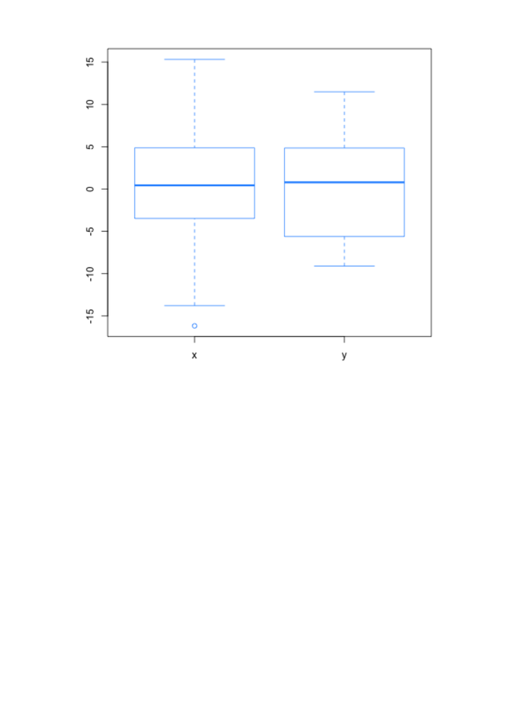

Figure 5.1 Boxplots that look similar

but if you overlay the actual data points you can see that they have very

different distributions.

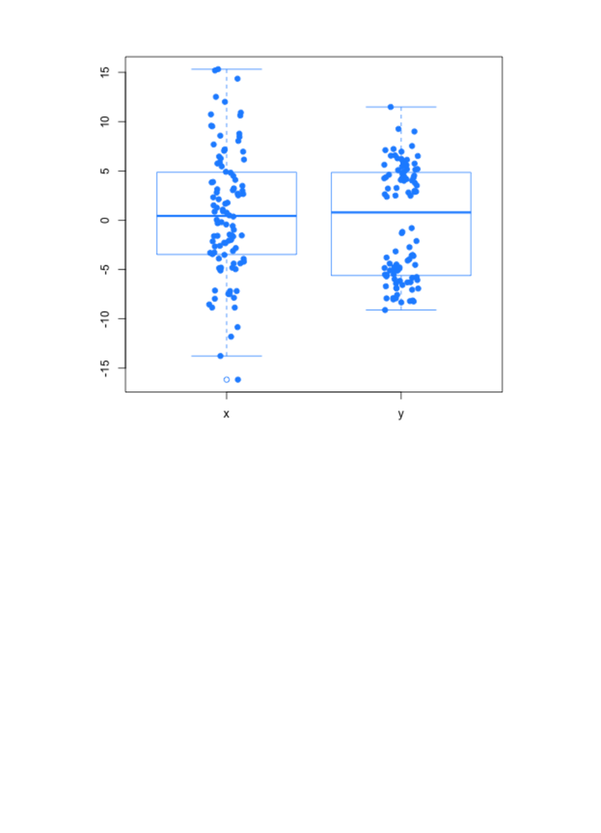

Figure 5.2 Boxplots that look similar with points overlayed

Plotting more of the data allows you to identify outliers, confounders,

missing data, relationships, and correlations much more easily than with

summary measures.

5.3 Exploratory graphs and tables should be made

quickly

Unlike with figures that you will distribute, you are only communicating

with yourself. You will be making many graphs and figures, the goal is

speed and accuracy at the expense of polish. Avoid spending time on

making axis labels clear or spending time on choosing colors. Find a color

palette and sizing scheme you like and stick with it.

5.4 Plots are better than summaries

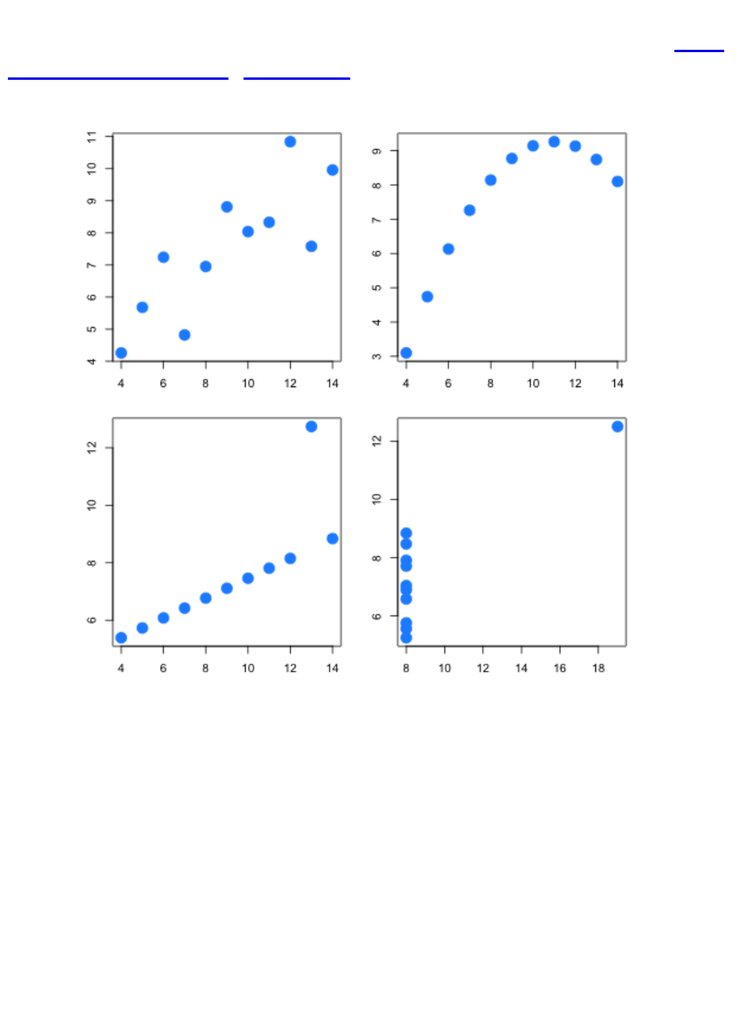

You can explore data by calculating summary statistics, for example the

correlation between variables. However all of these data sets have the exact

same correlation and regression line.

Figure 5.3 Data sets with identical correlations and regression lines

This means that it is often better to plot, rather than summarize, the data.

5.5 For large data sets, subsample before plotting

In general, most trends you care about observing will be preserved in a

random subsample of the data.

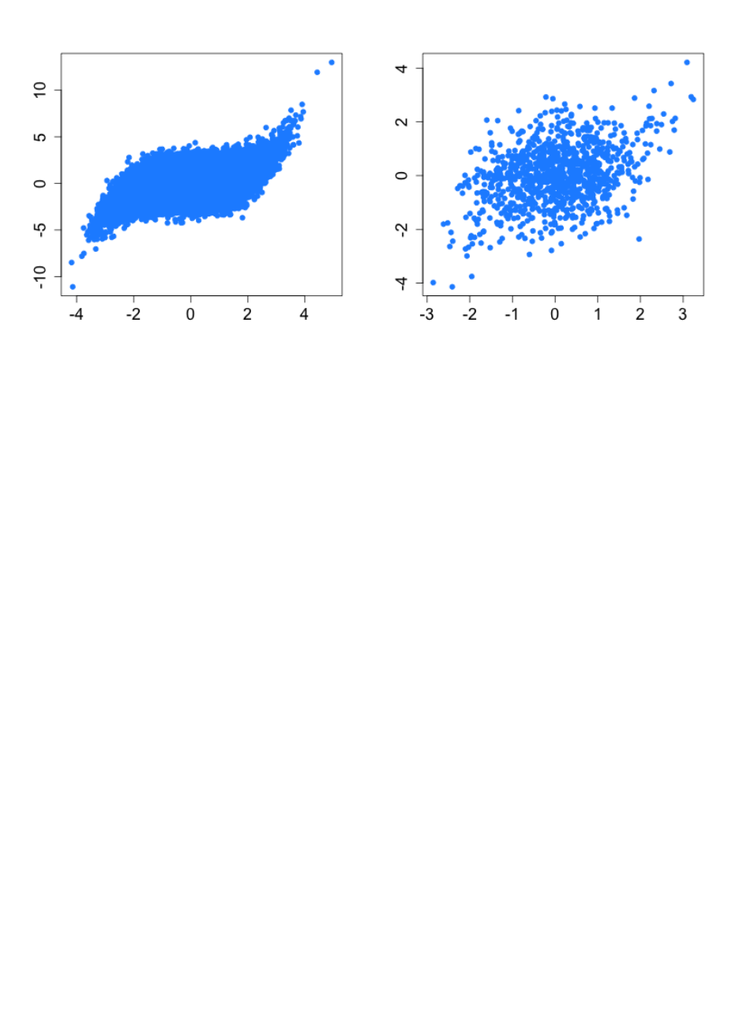

Figure 5.4 A large data set and a random subsample

5.6 Use color and size to check for confounding

When plotting the relationship between two variables on a scatterplot, you

can use the color or size of points to check for a confounding relationship.

For example in this plot it looks like the more you study the worse score

you get on the test:

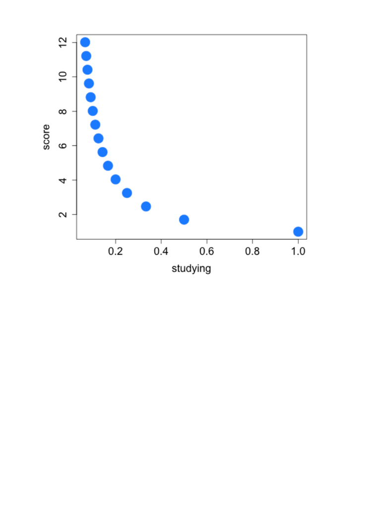

Figure 5.5 Studying versus score

but if you size the points by the skill of the student you see that more skilled

students don’t study as much. So it is likely that skill is confounding the

relationship

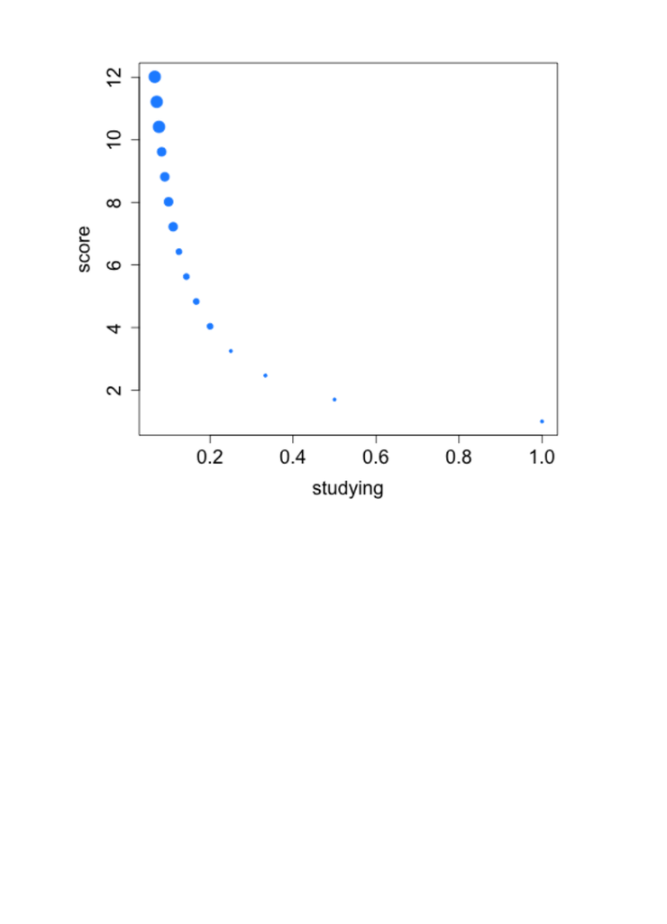

Figure 5.6 Studying versus score with point size by skill level

5.7 For multi-panel plots of the same data type fix the

axis

When making multiple plots of the same data type for comparison

purposes, having varying axes will place the points on different scales and

make them difficult to interpret.

5.8 For multi-panel plots match the comparison axis

If you are comparing two plots on their y-axis values, then the plots should

be side by side. If you are comparing the two plots on their x-axis values

the plots should be placed vertically on top of each other.

5.9 Use log transforms to “spread out” data with varying

orders of magnitude

[figure not shown]

Data measured across multiple scales will often be highly skewed, with

many values near zero. One way to “spread the values out” is to take the log

transform of the data. To avoid zeros you can take log(data + c) where c

is a small positive constant. But be careful about interpreting the spread of

the data on the log scale.

5.10 Use log transforms for ratio measurements

Taking the log of ratio-valued data will often make the distribution more

symmetric. Since the log of one is also zero, values of zero on the log scale

can be interpreted as equality of the two values in the ratio.

5.11 When comparing two measurements of the same

thing - use Bland Altman plots

If you have two ways of measuring the same quantity and you want to see if

they agree, use a Bland-Altman plot. So instead of plotting x versus y, plot

x+y versus x-y. Then differences between the two variables will be on the y

axis - so you hope all the values will be near zero (Figure 5.7, adapted from

gismoskater97). It also makes it easier to see if there are magnitude effects,

for example when small values of x and y are more similar than large values

of x and y.

5.12 Common mistakes

5.12.1 Optimizing style too quickly

The goal is to quickly understand a data set, during exploratory data

analysis speed is more important than style, so tools that make beautiful

graphics but take time should be avoided.

5.12.2 False pattern recognition

One of the most common mistakes in exploratory data analysis is to identify

and interpret a pattern without trying to break it down. Any strong pattern

in a data set should be checked for confounders and alternative

explanations.

5.12.3 Failing to explore data and jumping to statistical tests

A common failure, particularly when using automated software, is to

immediately apply statistical testing procedures and to look for statistical

significance without exploring the data first.

5.12.4 Failing to look at patterns of missing values and the

impact they might have on conclusions.

Missing data are often simply ignored by statistical software, but this means

that if the missing data have informative patterns, then analyses will

ultimately be biased. As an example, suppose you are analyzing data to

identify a relationship between geography and income in a city, but all the

data from suburban neighborhoods are missing.

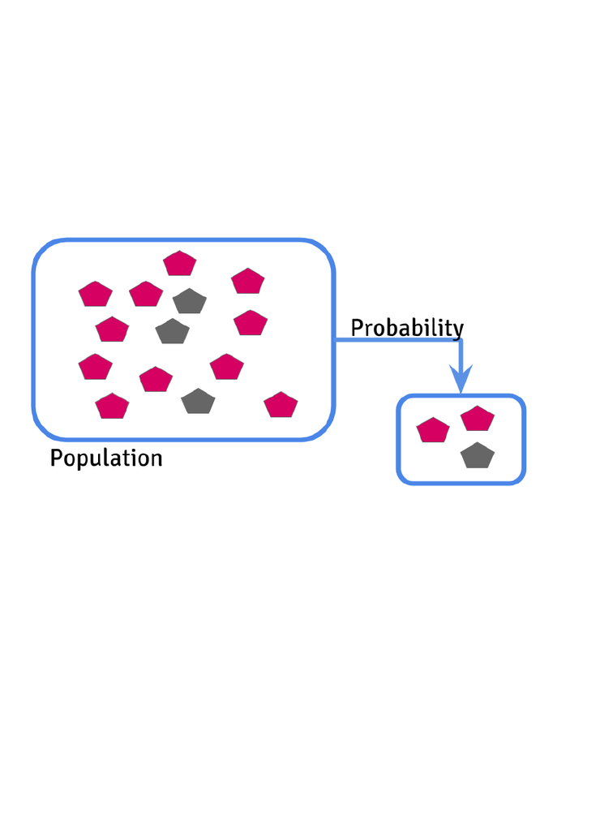

6. Statistical modeling and inference

The central goal of statistical modeling is to use a small subsample of

individuals to say something about a larger population. The reasons for

taking this sample are often the cost or difficulty of measuring data on the

whole population. The subsample is identified with probability (Figure 6.1).

Figure 6.1 Probability is used to obtain a sample

Statistical modeling and inference are used to try to generalize what we see

in the sample to the population. Inference involves two separate steps, first

obtaining a best estimate for what we expect in the population (Figure 6.2).

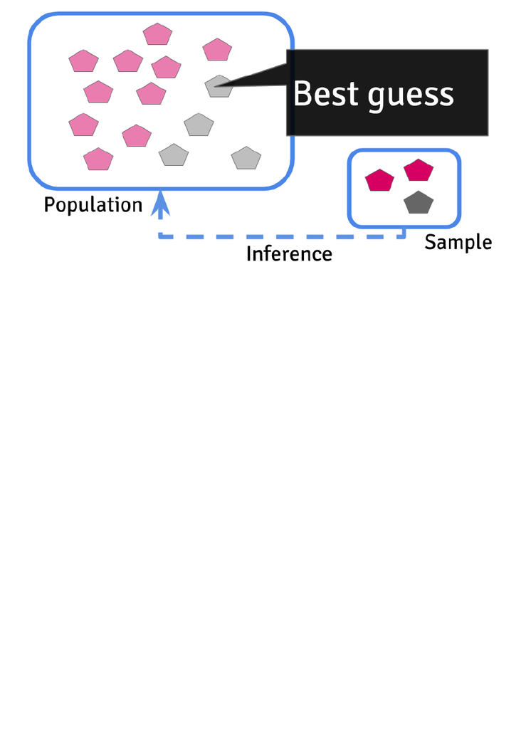

Figure 6.2 The first step in inference is making a best estimate of what is happening in the

population

Inference is also used to quantify how uncertain we are about the quantity

we are estimating (Figure 6.3). This uncertainty could be due to multiple

sources including the fact that we only have a sample of the population, the

technology we used to measure the data, or natural variation between the

individuals being measured. Good statistical models account for all of these

sources of variation.

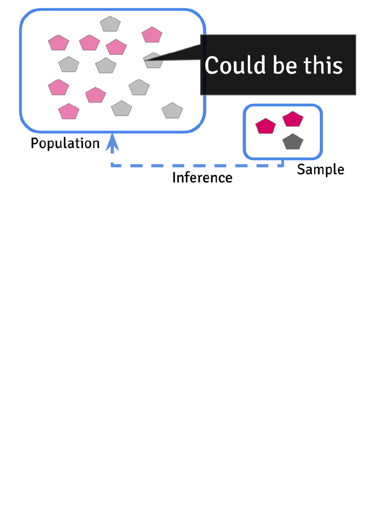

Figure 6.3 The second step in inference is estimating how uncertain we are about our estimate

6.1 When possible, perform exploratory and

confirmatory analysis on separate data sets

If you plan to explore a data set for new relationships without an a priori

model or hypothesis, split your data into two random subsamples. Perform

exploration on the first part of the data and confirm that any relationships

you detect appear in the second part at the end of your analysis. A typical

split is 70% for discovery and 30% for validation. This splitting is ideal it

may lead to loss of power and may not always be possible.

6.2 Define the population, sample, individuals and data

In a clinical trial, for example, you might say that the population is all

people who might take a drug for diabetes. The sample is the subset of

people that we will enroll in the trial, the individuals (sometimes called

sampling units) are the people in the trial, and the data are the

measurements on the people.

6.3 Identify reasons your sample may not represent the

population

If you take a completely random sample from the population it will be

representative or it will be possible to understand how it is not

representative of the population. However, it is often impossible to sample

randomly from a population. So people make samples based on

convenience, cost, and time. Be sure to report all reasons the sample may

not represent the population.

6.4 Identify potential confounders

If you measure the shoe size and literacy of a random subsample of people

from the United States, they will be correlated. The reason is that young

people are less literate than old people and also have smaller shoes. Age is

related to both literacy and shoe size and is a confounder for that

relationship. When you observe a correlation or relationship in a data set,

consider the potential confounders - variables associated with both variables

you are trying to relate.

6.5 Check the distribution of missing data

Determine whether missing values are associated with any of the variables

you have in your data set. Associations detected between two variables may

be distorted if the presence of missing values for one variable is correlated

with the second.

6.6 Check for outliers

Values that are outside of the common range for a single variable may lead

to apparently large relationships in summary statistics like correlations or

regression coefficients.

6.7 Confirm that estimates have reasonable signs and

magnitudes

If you observe that for every increase of one year in education you get an

estimate of $1,000,000 more dollars of yearly income, it is likely there is a

problem with the data set or your analysis. Similarly if people who exercise

more are dramatically more obese than those who do not, it suggests there

may be a data problem.

[figure not shown]

6.8 Be careful of very small or very large samples

In both very small and very large sets of data, estimates of uncertainty

should be used with caution. In very small data sets there is not enough data

to make an accurate measure of uncertainty. In very large data sets, the

measure of uncertainty will be accurate, but the question may no longer be

how uncertain we are about estimates - we will be very certain about them.

In this case one can focus exclusively on whether the value of the estimate

is meaningful, or meaningfully different from some other value - rather than

potential uncertainties.

6.9 When performing multiple hypothesis tests, correct

for multiple testing

Classic hypothesis tests are designed to call results significant 5% of the

time, even when the null is true (e.g. nothing is going on). One really

common choice for correcting for multiple testing is to use the false

discovery rate to control the rate at which things you call significant are

false discoveries. People like this measure because you can think of it as the

rate of noise among the signals you have discovered. This error rate is most

widely used when there are potentially many true discoveries.

Another common error rate is the family wise error rate which is the

probability of making even one false significant call among all the tests you

perform. The standard approach to controlling the family wise error rate is

the Bonferroni correction.

More test results will be called significant with the false discovery rate than

with the family wise error rate, but the significant results may include more

false positives.

6.10 Smooth when you have data measured over space,

distance, or time

This is one of the oldest ideas in statistics - regression is a form of

smoothing. I personally like locally weighted scatterplot smoothing a lot.

Some common smoothers are smoothing splines, moving averages, and

loess.

6.11 Know your real sample size

It can be easy to be tricked by the size of a data set. Imagine you have an

image of a simple black circle on a white background stored as pixels. As

the resolution increases the size of the data increases, but the amount of

information may not (hence vector graphics). Similarly in genomics, the

number of reads you measure (which is a main determinant of data size) is

not the sample size, it is the number of individuals. In social networks, the

number of people in the network may not be the sample size. If the network

is very dense, the sample size might be much less. In general the bigger the

sample size the better and sample size and data size aren’t always tightly

correlated.

6.12 Common errors

6.12.1 Failing to account for dependencies

If data are measured across time, across space they will likely be dependent.

Before performing inference each variable should be plotted versus time to

detect dependencies, and similarly for space. Similarly, identifying potential

confounders should occur before model fitting.

6.12.2 Focusing on p-values over confidence intervals

P-values can be a useful measure of statistical significance if used properly.

However, a p-value alone is not sufficient for any convincing analysis. A

measure of inference on a scientific scale (such as confidence intervals or

credible intervals) should be reported and interpreted with every p-value.

6.12.3 Inference without exploration

A very common mistake is to move directly to model fitting and calculation

of statistical significance. Before these steps, it is critical to tidy, check, and

explore the data to identify dataset specific conditions that may violate your

model assumptions.

6.12.4 Assuming the statistical model fit is good

Once a statistical model is fit to data it is critical to evaluate how well the

model describes the data. For example, with a linear regression analysis it is

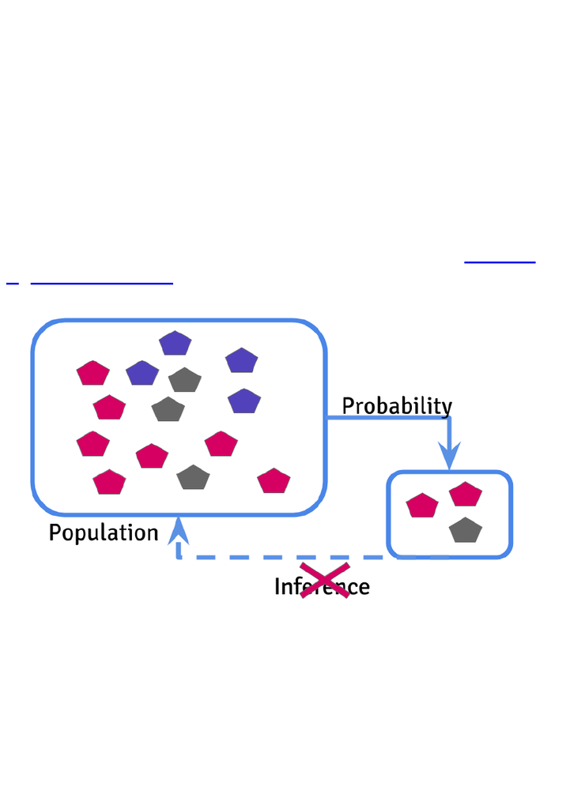

critical to plot the best fit line over the scatterplot of the original data, plot

the residuals, and evaluate whether the estimates are reasonable. It is ok to

fit only one statistical model to a data set to avoid data dredging, as long as

you carefully report potential flaws with the model.

6.12.5 Drawing conclusions about the wrong population

When you perform inference, the goal is to make a claim about the larger

population you have sampled from. However, if you infer to the wrong

population or if the population changes after you take your sample, all of

your results will be biased (Figure 6.4). A recent example is when Google

Flu trends created a prediction algorithm to predict flu cases based on

search terms. When people started searching differently, the prediction

algorithm broke down.

Figure 6.4 If you infer to the wrong population bias will result.

6.12.6 Not addressing uncertainty

If you report an estimate without a measure of uncertainty, then you are

claiming that you know the exact value of that parameter. For example, if

you report the average height of men in the United States is 5’8” based on

your analysis with no measure of uncertainty, then you are claiming you

measured the height of every man in the United States and know the exact

value.

6.12.7 Identifying real correlations you don’t care about

In many cases, it is possible to identify two variables that are really

correlated due to a confounder or some spurious relationship. A common

example is the relationship between ice cream sales and murder in large

cities. This correlation is real and reproducible across cities, but is due to

the fact that high temperatures lead to both more murders and more ice

cream sales. While this correlation is real, it isn’t one you care about. This

is related to the problem of not reporting confounders.

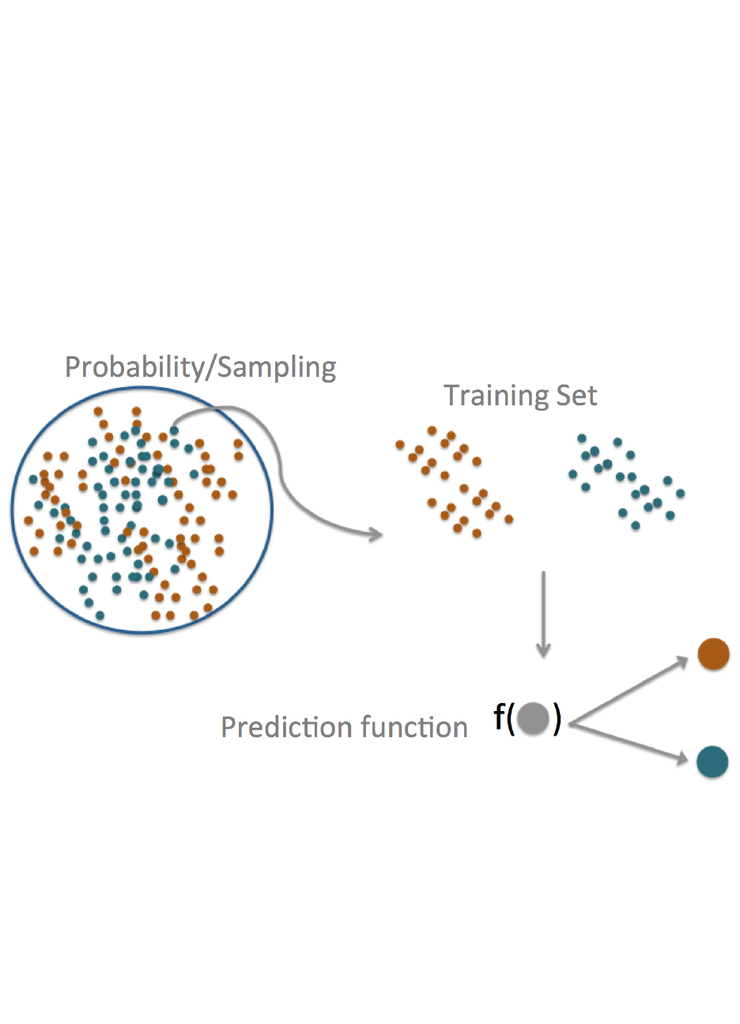

7. Prediction and machine learning

The central idea with prediction is to take a sample from a population - like

with inference - and create a training data set. Some variables measured on

the individuals in the training set are called features and some are outcomes.

The goal of prediction is to build an algorithm or prediction function that

automatically takes the feature data from a new individual and makes a best

guess or estimate about the value of the outcome variables (Figure 7.1).

Figure 7.1 How prediction works

7.1 Split the data into training and validation sets

Before performing any analysis at all, split the data into training and

validation sets. A typical split is 70% in training and 30% in validation.

Then put the validation data set aside and ignore it until the very end. Once

you have finalized all parts of your model, apply it once and only once to

[figure not shown]

the validation data set to estimate the real error rate of your prediction

algorithm.

7.2 Identify reasons your sample may not represent the

population

If you take a completely random sample from the population it will be

representative. However, it is often impossible to sample randomly from a

population. So people make samples based on convenience, cost, and time.

If the sample used to create the training set differs from the population then

prediction functions will fail. An example is when Google Flu trends used

search terms to try to predict flu outbreaks. When people started using

search terms differently and the population changed, the prediction

algorithm failed.

7.3 More data usually beats better algorithms

In general collecting more, or more appropriate, data for a prediction

algorithm will improve accuracy much more than improving the prediction

algorithm itself. This has been called “the unreasonable effectiveness of

data”.

7.4 Features are more important than the algorithm

In general many out of the box prediction algorithms perform very similarly

on most data sets. The best way to improve accuracy is often to pick better

data and variables.

7.5 Define your error measure first

You may directly try to optimize a specific error rate, say by minimizing

root mean squared error. Or you may choose to weight different types of

errors differently. But you should define your error measure before starting

to model.

Accuracy, sensitivity, and specificity are typical for binary outcomes

(Figure 7.2, adapted from Wikipedia Sensitivity and Specificty for binary

outcomes]).

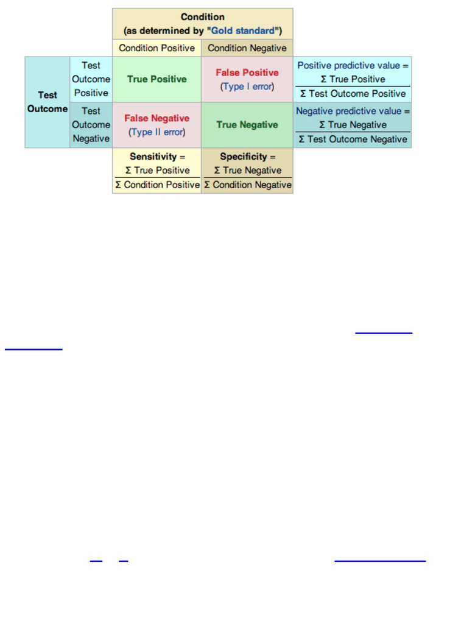

Figure 7.2 Common binary error rates

Root mean squared error is typical for continuous outcomes. That is the

square root of the sum of the squared difference between the prediction and

the true value.

7.6 Avoid overfitting with cross validation

To avoid tuning your model too closely to the observed data use cross-

validation or subsampling. The basic idea is to split your training set up into

two sets randomly, build different models on the first piece, and try them on

the second set, picking the model that performs best.

7.7 If the goal is prediction accuracy, average many

prediction models together.

In general, the prediction algorithms that most frequently win prediction

competitions blend multiple models together by averaging. The idea is that

by averaging (or majority voting) multiple good prediction algorithms you

can reduce variability without giving up bias. One of the earliest

descriptions of this idea was of a much simplified version based on

bootstrapping samples and building multiple prediction functions - a

process called bagging (short for bootstrap aggregating). Random forests,

another successful prediction algorithm, is based on a similar idea with

classification trees.

[figure not shown]

7.8 Prediction is about tradeoffs

Interpretability versus accuracy

Speed versus accuracy

Simplicity versus accuracy

Scalability versus accuracy

In some areas one of these components may be more important than others.

The Netflix prize awarded $1,000,000 to the best solution to predicting

what movies people would like. But the winning solution was so

complicated it was never implemented by Netflix because it was

impractical.

8. Causality

The gold standard for causal data analysis is to combine specific

experimental designs such as randomized studies with standard statistical

analysis techniques. If correctly performed, the experimental design makes

it possible to identify how variables affect each other on average.

8.1 Causal data analysis of non-randomized experiments

is often difficult to justify.

Causal data analysis in observational studies requires both more technical

statistical analyses and belief that untestable and often unrealistic

assumptions are met. Phenomena that are not easily studied with

randomized studies, such as pregnancy or carcinogenesis, frequently

produce spurious causal data analyses that don’t hold up to scrutiny.

8.2 Even randomized studies may be difficult to interpret

causally

Some common difficulties in clinical trials are: (1) patient dropout

preferentially by treatment, (2) unblinding of trials - when the

experimenters or subjects discover what treatment they are part of, (3)

treatments that are difficult to take or adhere to, so just the intent to treat a

person must be used as the treatment itself. All of these issues make causal

analysis difficult even in randomized studies.

8.3 For randomized studies use exploratory analysis to

confirm the randomization “worked”

Make tables and plots to ensure all non-randomized variables measured on

each subject have approximately the same distribution between the groups,

including missing values.

8.4 Causal data analyses seek to identify average effects

between often noisy variables.

Decades of data show a clear causal relationship between smoking and

cancer. If you smoke, it is a sure thing that your risk of cancer will increase.

But it is not a sure thing that you will get cancer. The causal effect is real,

but it is an effect on your average risk.

8.5 Unless you have performed a randomized experiment

or use causal techniques avoid causal language

Causality creep is the idea that causal language is often used to describe

inferential or predictive analyses. Avoid using words like “cause”, “effect”,

or “leads to an increase” if you have not performed a causal analysis.

8.6 Common mistakes

8.6.1 Causality creep

A common mistake is to perform an analysis that looks for a correlation or

association between measurements in a non-randomized study, then

interprets that correlation as a causal relationship. For example, if you

identify the well-known correlation between ice cream scales and murder,

interpreting the correlation as “ice cream sales lead to increased homicide

rates”.

9. Written analyses

Data analysis is as much about communication as it is about statistics. A

written data analysis report should communicate your message clearly and

in a way that is readable to non-technical audiences. The goal is to tell a

clear, precise and compelling story. Throughout your written analysis you

should focus on how each element: text, figures, equations, and code

contribute to or detract from the story you are trying to tell.

9.1 The elements of a written analysis

A written analysis should always include

A title

An introduction or motivation

A description of the statistics or machine learning models you used

Results including measures of uncertainty

Conclusions including potential problems

References

9.2 Lead with the question you are answering

Before explaining the data, models, or results, lead with the question that

you are trying to answer. The question should be a scientific or business

application - not a statistical or computational question. A good example

would be, “Can we use tweets about stocks to predict stock prices?”

9.3 Describe the experimental design

Explain where the data came from, how they were collected, and relevant

information about the technologies and systems used to collect the data.

9.4 Describe the data set

Explain what processing you did to the data, and the tidy data you

produced. It is common to lead with a table summarizing the variables in

the tidy data set, including sample sizes, number of variables, averages and

variances or standard deviations for each variable. This component of an

analysis is critical to identify data versioning issues.

9.5 When describing a statistical model use equations or

psuedocode

Every model must be mathematically specified. This model may be

specified in the main text of the writing if the audience is statistical or in an

appendix if the audience is non-technical.

Modeling procedures should be completely specified using equations or

algorithms with explicit definitions of each input and output. Each term and

index in the equation should be explained in plain language. When possible,

use letters and symbols that are abbreviations of the variables in your

model. For example, if modeling the relationship between weight and

height you might write the model W = a + b H + e and then explain that W

stands for weight, a is the weight for a person with 0 height, b is the

increase in weight units for a person with one additional height unit, H is

the height of the person, and e is measurement error or noise.

9.6 Specify the uncertainty distribution

You should declare the distribution of the error terms like e and the

assumptions you are making about those errors - specifically whether they

are independent or dependent and whether they have common variance or

are heteroskedastic.

9.7 For each parameter of interest report an estimate and

interpretation on the scale of interest

When reporting an estimate do not say that we estimated a=3, instead

report that we estimated a change of 3 pounds in weight for one inch in

height.

9.8 For each parameter report a measure of uncertainty

on the scientific scale

For every estimate you report you should report a measure of uncertainty on

the scale of interest. Report that a 95% confidence interval for the estimated

measures of uncertainty are standard deviations, confidence intervals, or

credible intervals.

9.9 Summarize the importance of reported estimates

When reporting an estimate, also report why you calculated the estimate

and what the quantitative value means.

9.10 Report potential problems with the analysis

If you fit a model and you observe that there may be missing data, or that

outliers may be driving a particular estimate, report that as part of the

analysis.

9.11 Do not report every analysis you performed

Many analyses, particularly exploratory analyses, will not be useful to

explaining your result and interpretation. Before including an analysis in the

final report, ask whether it contributes to the story or explains a crucial fact

about the data set that can’t be left out.

9.12 Every statistical or machine learning method should

be referenced

When using models it is important to give credit to the person who

developed them. It is also important so that the reader can go back to the

original source of the model and understand it.

There is a convention that some statistical methods are not cited like

maximum likelihood or least squares - but at minimum a reference to a

textbook should be made when using even common techniques.

10. Creating figures

Figures ar graphs you are likely to share with other people or include in

reports. They are used to communicate with others what we observed or

discovered in the data set. The goal for figures is that when viewed with an

appropriately detailed caption, they can stand alone without any further

explanation as a unit of information. There are several basic principles

behind creating useful expository graphs.

10.1 Information should be communicated as often as

possible with position, and on common scales.

The reason why statisticians don’t like pie-charts is that comparing angles is

notoriously hard. In Figure 10.1 which slice is bigger A or D?

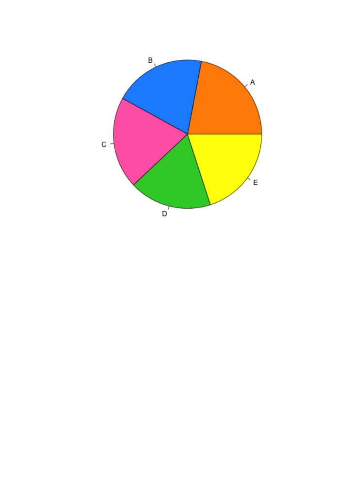

Figure 10.1 A pie chart

If we make this as a barchart it is much easier to see that A is bigger than D

(Figure 10.2).

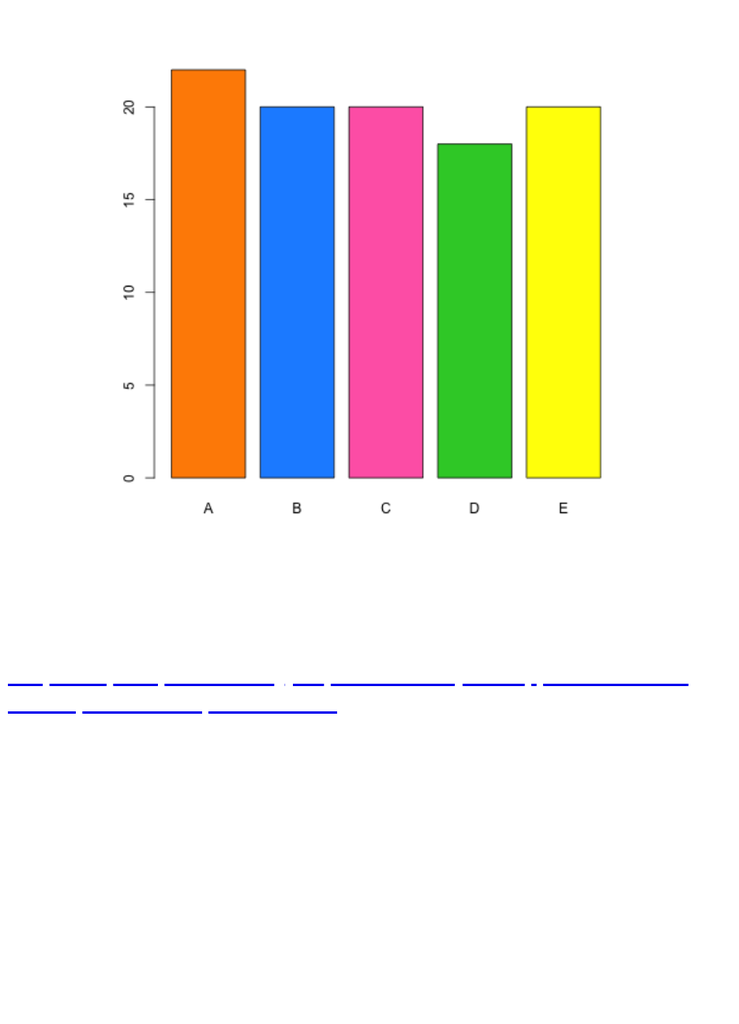

Figure 10.2 A bar chart

This is actually a more general phenomenon. There are a large number of

visual tasks you could use when making plots (Figure 10.3, adopted from

Graphical perception: Theory, Experimentation, and Applications to the

Development of Graphical Models). It turns out that humans are best at

perceiving position along a single axis with a common scale.

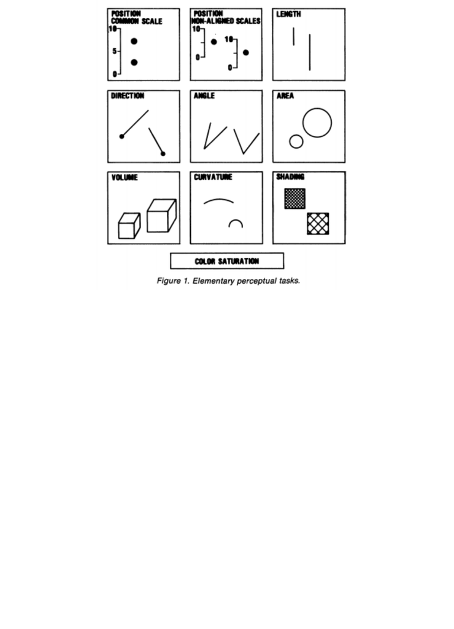

Figure 10.3 Visual tasks

10.2 Low information density should be avoided

The most extreme example of this is a plot with a single point. It is better to

just report the data value. But any graph that is primarily white space and

doesn’t illustrate a key feature of the data should be avoided.

10.3 Gratuitous flourishes should be avoided

When creating figures for papers, it is a good idea to make them visually

pleasing with a nice color palette and good choices for the shape of points

and fonts. However, gratuitous flourishes like 3-d barcharts, 3-d pie charts,

or animation for no reason should be avoided.

10.4 Color and size may both be used to communicate

information.

Color and size may both used, be used for communication. A common

approach is to plot a scatterplot of two variables, where the points are

colored or sized by a third. Color and size should be used to communicate

information, although the choices can also be made on the basis of style and

with the goal of making figures interesting.

10.5 When there are many values of a third variable use

faceting

In some cases, there are too many values of a third variable to view in a

single plot. When this happens, facet the plot by making multiple panels,

one panel each for different values of the third variable.

10.6 Axis labels should be large, easy to read, in plain

language

For figures and expository graphs, axis labels should be in large type and

easily readable. In addition, the axis labels should not be variable names.

For example instead of using the value “x$hght” or “x[1,]”, which may be

the default from software, use “Height”.

10.7 Include units in figure labels and legends

When labeling a variable in a figure, always include units, for example

“Height (cm)”.

10.8 Use figure legends

When size or color are used to distinguish points, include a figure legend

that labels any scales or colors used in plain language.

10.9 Figure legends in the figure are preferred

When possible, directly label point clouds, distributions, or other features of

a plot in the plot itself, without using a separate figure legend.

10.10 Figure titles should communicate the message of

the plot

A title should be used to communicate the main take home message of a

plot. For example if you plot the relationship between studying and grades,

your figure title might read, “More studying is associated with improved

[figure not shown]

grades”. Eliminate titles that simply describe the data, for example,

“Studying versus grades”.

10.11 Label multi-panel plots with numbers or letters

If you make a plot with multiple panels always include numbers or letters

for each panel so each component of the plot can be individually referred to

without resorting to descriptions like, “the scatterplot in the upper right

hand corner”.

10.12 Add text to the plot itself to communicate a

message

To make a figure stand alone it is often helpful to label specific trends or

features of the data that are relevant to the person looking at the graph. For

example:

[figure not shown]

Figure 10.4 An in graph label

10.13 Figure captions should be self-contained

A person should be able to understand from your figure caption everything

they need to know about your graph. So you should explain at minimum

what the x and y axis are, what their units are, what all colors and sizes in

the graph mean, and in particular any trends you expect them to observe in

the figure.

10.14 Common errors

10.14.1 Using a color palette that colorblind people can’t see

A common mistake is to use red and green to indicate different things on

the same plot. There are many web tools available for uploading figures you

have made to check whether they are visible to color-blind people.

10.14.2 Using colors that look too similar to each other

In general avoid using colors that appear very similar (red and pink, blue

and light blue) for making plots. Try to use colors that are clearly different.

10.14.3 Not making scatterplots when you should

Scatterplots are one of the most informative type of plot since it shows each

individual data value. When possible, scatterplots should be used in favor of

boxplots or barplots. Even when using these more summarized versions of

the data, overlaying the data points can be useful.

10.14.4 Failing to take logs.

When data are highly skewed and you make a plot without taking the log

transform first, a large amount of the data will be clustered in the corner of

the plot so most of the patterns in the data will be obscured (Figure 10.5,

adopted from Displaying data badly.

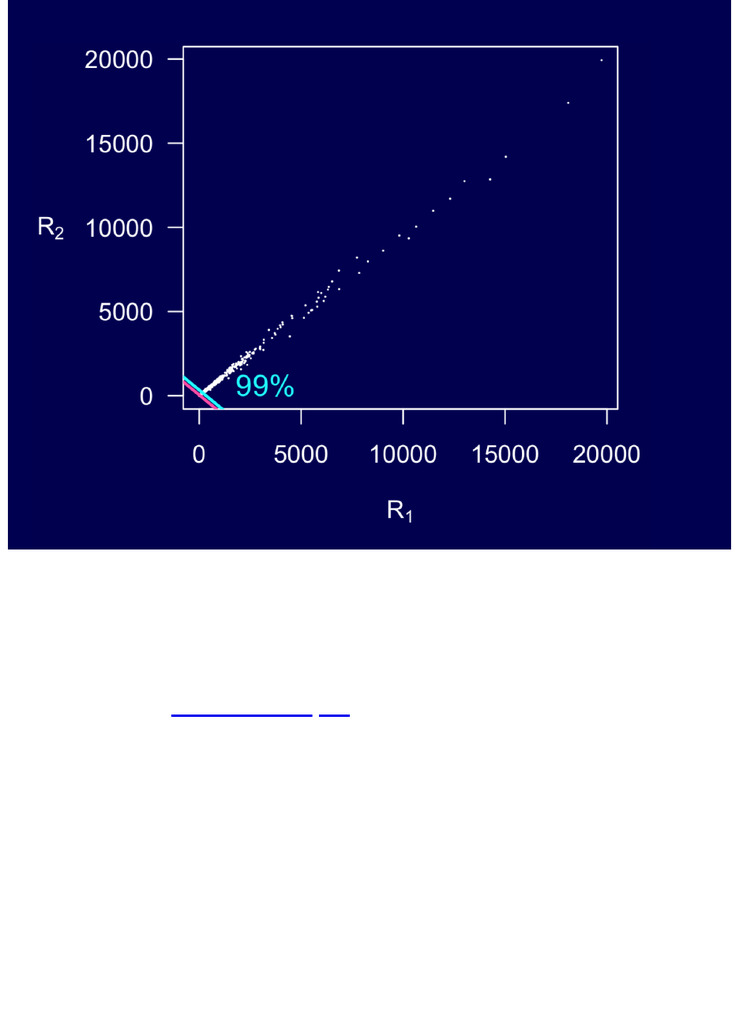